# Simulation exercise in **Genomik und Bioinformatik**

## Part D

**Learning objectives:**Scaling of genes in expression matrices for visualization Load the tle *geneExpressionData.rda* in an R session to and, interprete and visualize a matrix of microarray gene expression data measured from lymphoma patients.

**Question (a):** In which object can you nd the matrix? How many rows and columns are in this matrix? What do columns and rows correspond to? Explain your answers. Hint: the matrix is extracted from the GEO dataset GSE4475 treated in exercise B of assignment 4.

```r
> load(file= "C:/Users/aleX/Kurse/genomik/Blatt5/geneExpressionData.rda")
> genes <- geneExpressionData
> str(genes)
```

```
##  num [1:137, 1:135] 10.15 10.61 11.19 6.67 10.47 ...
##  - attr(*, "dimnames")=List of 2
##   ..$ : chr [1:137] "201172_x_at" "201502_s_at" "200905_x_at" "212338_at" ...
##   ..$ : chr [1:135] "MPI-001" "MPI-002" "MPI-003" "MPI-005" ...
```

```r
> dim(genes)
```

```
## [1] 137 135
```

**Answer:** *geneExpressionData* is just a matrix with 137 rows and 135 columns. The rows and columns present genes and samples respectively.

**Question (b):** Visualize the gene expression matrix using the command `image`. How can you make sure that the rows of the matrix are horizontal and the columns are vertical? How can you show names of genes at the right axis and names of samples at the bottom axis instead of the default labeling? Which color represents high expression, which color low expression? Describe your most striking observation.

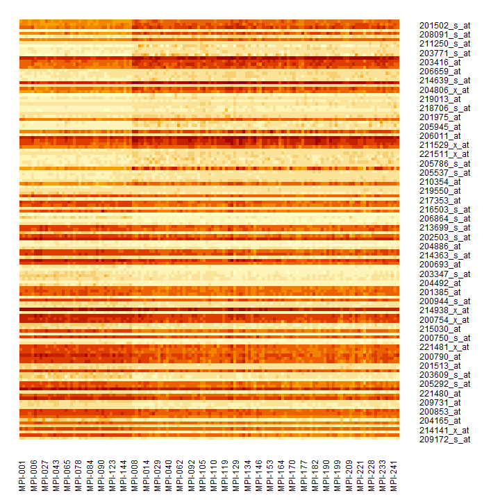

```r
> x_axis <- dim(genes)[1]
> y_axis <- dim(genes)[2]
> genes_rot <- t(genes)[,nrow(genes):1]
> par(mar=c(3,1,1,5))
> image(1:y_axis, 1:x_axis, genes_rot, axes=FALSE, xlab="", ylab="")
> axis(side=4, at = 1:x_axis, labels=rev(rownames(genes)),las=2,tick=FALSE,cex.axis=0.5)
> axis(side=1, at = 1:y_axis, labels=colnames(genes),las=2,tick=FALSE,cex.axis=0.5)
```

**Question (c):** For each gene expression value, subtract the mean expression of that gene across all samples. What do you observe now looking at the expression matrix?

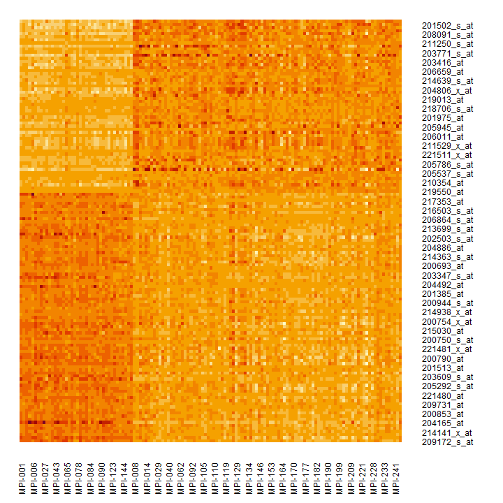

```r
> genes_shift <- t(apply(genes, 1, function(x) x-mean(x)))
> genes_shift_rot <- t(genes_shift)[,nrow(genes_shift):1]
>
> par(mar=c(3,1,1,5))
> image(1:y_axis, 1:x_axis, genes_shift_rot, axes=FALSE, xlab="", ylab="")
> axis(4, at = 1:x_axis, labels=rev(rownames(genes)),las=2,tick=FALSE,cex.axis=0.5)
> axis(1, at = 1:y_axis, labels=colnames(genes),las=2,tick=FALSE,cex.axis=0.5)
```

**Answer:** The matrix is now clearly divided into four quadrants.

**Question (d):** In addition, divide all values in a row by its standard deviation. Does this still sharpen the picture? Are there distinct groups of samples? If yes, how many different groups do you see and how many samples are attributed to each group? What about the genes, do they form clusters? How large are they?

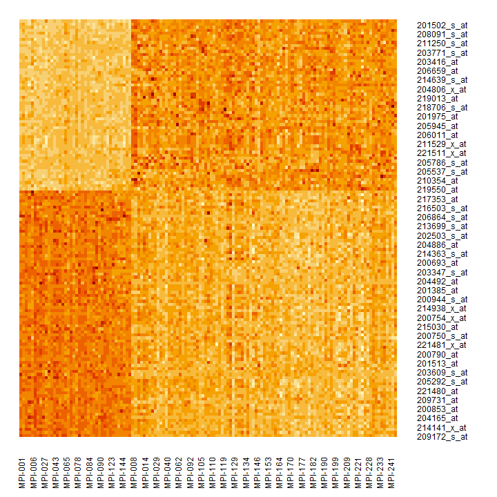

```r
> genes_shift_sd <- t(apply(genes_shift, 1, function(x) x/sd(x)))
> genes_shift_sd_rot <- t(genes_shift_sd)[,nrow(genes_shift_sd):1]
>
> par(mar=c(3,1,1,5))
> image(1:y_axis, 1:x_axis, genes_shift_sd_rot, axes=FALSE, xlab="", ylab="")
> axis(4, at = 1:x_axis, labels=rev(rownames(genes)),las=2,tick=FALSE,cex.axis=0.5)
> axis(1, at = 1:y_axis, labels=colnames(genes),las=2,tick=FALSE,cex.axis=0.5)
```

```r
> samples_group <- which(genes_shift_sd==genes_shift_sd[1,"MPI-008"])%/%nrow(genes_shift_sd)
> samples_group
```

```
## [1] 40
```

```r
> gene_group <- which(genes_shift_sd==genes_shift_sd["219550_at",1])
> gene_group
```

```
## [1] 56
```

**Question (e):** What is helpful and what is wrong with the call: `geneExpressionData <- scale(geneExpressionData)` Fix the call in order to obtain the same result as the programming in sections (c) and (d).

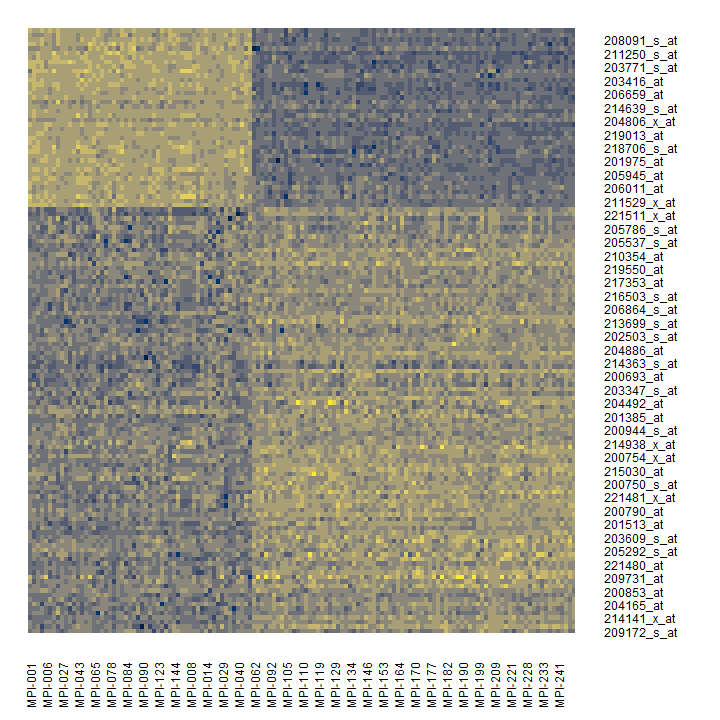

```r
> scale_genes2 <- scale(t(genes))
> scale_genes_rot2 <- t(scale_genes2)[,nrow(scale_genes2):1]
> par(mar=c(3,1,1,5))
> image(1:x_axis, 1:y_axis, scale_genes_rot2, axes=FALSE, xlab="", ylab="", col = hcl.colors(10, "Cividis", rev = TRUE))
> axis(4, at = 1:x_axis, labels=rev(rownames(genes)),las=2,tick=FALSE,cex.axis=0.5)
> axis(1, at = 1:y_axis, labels=colnames(genes),las=2,tick=FALSE,cex.axis=0.5)
```

**Answer:** The function `scale` applies to columns. Since we want to apply it to rows we need to first transpose the matrix with `t()`.

**Question (f):** Adapt the coloring of your image close to the color usage of the heatmap shown on slide 23 of the lecture’s chapter on “Gene Expression”.

**Answer:** The function `hcl.pals()` shows all available color palettes. In `image` the color parameter can adjusted. Here “Cividis” was chosen as it was the closest that resembled the one given in the lecture. Palettes can also be inspected here: https://colorspace.r-forge.r-project.org/articles/hcl_palettes.html.